[figure not shown]

# **Problem Defination**

### ✅ 1️⃣ **Business Problem**

The used-car market suffers from **large inconsistencies in pricing** across online platforms and regions.  
Buyers struggle to identify whether the listed price is fair or overpriced.  
This leads to **poor decisions, financial loss, and lack of market transparency**.

### ✅ 2️⃣ **Technical Problem**

Used car prices depend on multiple critical features such as:

- Brand & Model
- Manufacturing Year
- Mileage
- City & Fuel Type
- Transmission & Body Style

Traditional manual pricing **fails to process and analyze** all these interacting variables accurately.  
There is a need for an **intelligent data-driven model** trained on real market data to provide accurate price estimation.

### ✅ 3️⃣ **Project Goal**

Develop a **Machine Learning Regression Model** that predicts the **fair price** of a used car in Egypt based on its specifications and **historical market listings**.

### ✅ 4️⃣ **Solution Overview**

# **Dataset Description**

### CSV file - 9687 rows x 12 columns (Includes Price Columns as Target)

## **Attributes**

### Price: price of the care(Target Column)

#### url ,make ,model ,used since / year,km / mileage

#### Transmition ,city ,color,fuel,body shape

# **Data Collection & Integration**

### 1️⃣ **Data Source**

The dataset was collected through **Web Scraping** from major Egyptian used-car marketplaces:

- **Hatla2ee** → https://eg.hatla2ee.com/
- **ContactCars** → https://www.contactcars.com/

These websites provide real automotive listings from the Egyptian market, which ensures realistic and updated pricing data.

### 2️⃣ **Scraping Methodology**

The scraping process was implemented using:

- **Python**
- **BeautifulSoup** for HTML parsing
- **Requests** for fetching page content

We extracted data for each car listing including:

- Technical Specifications
- Pricing Information
- Seller Listing Details

### 4️⃣ **Data Cleaning**

After extraction, the data underwent several preprocessing steps:

- Removing **duplicate** entries
- Handling **missing** values
- Standardizing text formats (brand/model names)
- Converting **numeric fields** (e.g., mileage, price) to proper data types

### 5️⃣ **Data Integration (SQL)**

Multiple tables scraped from both websites were **merged together** using:

> **SQL JOIN operations**

Purpose:

- Combine specifications & price data into one structured dataset
- Remove separated or incomplete car entries
- Make the dataset ready for **Analytics** & **Machine Learning Models**

### ✅ **Final Output**

A unified, clean, and well-structured dataset containing:

- Real used-car market insights in Egypt
- Accurate pricing to support **Price Prediction Models**

This dataset is fully prepared for:

- Data Exploration
- Feature Engineering
- Model Training & Evaluation

# coding: utf-8

# -*- coding: utf-8 -*-

```python
data=pd.read_csv("finalllll_cleaned_FINAL_READY_v6.csv")
```

# **Model Workflow**

```python
import pandas as pd
import numpy as np
import matplotlib.pyplot as plt
import seaborn as sns
import warnings
warnings.filterwarnings('ignore')
```

```python
from sklearn.model_selection import train_test_split
from sklearn.linear_model import LinearRegression
from sklearn.metrics import mean_squared_error, r2_score
```

```python
data=pd.read_csv("finalllll_cleaned_FINAL_READY_v6.csv")
```

```python
data.head(3)
```

```python
data.info()
```

```
<class 'pandas.core.frame.DataFrame'>
RangeIndex: 9687 entries, 0 to 9686
Data columns (total 12 columns):
 #   Column         Non-Null Count  Dtype
---  ------         --------------  -----
 0   URL            9687 non-null   object
 1   Price          9687 non-null   int64
 2   Date           9687 non-null   object
 3   Make           9687 non-null   object
 4   Model          9687 non-null   object
 5   Year           9687 non-null   int64
 6   Mileage_in_KM  9687 non-null   int64
 7   Transmission   9687 non-null   object
 8   City           9687 non-null   object
 9   Color          9687 non-null   object
 10  Fuel_Type      9687 non-null   object
 11  Body_Style     9687 non-null   object
dtypes: int64(3), object(9)
memory usage: 908.3+ KB
```

```python
data.describe()
```

|  | Price | Year | Mileage_in_KM |
| --- | --- | --- | --- |
| count | 9.687000e+03 | 9687.000000 | 9687.000000 |
| mean | 1.029480e+06 | 2015.481573 | 137008.140085 |
| std | 9.058503e+05 | 7.068881 | 94354.404646 |
| min | 1.000000e+04 | 1990.000000 | 1.000000 |
| 25% | 4.500000e+05 | 2011.000000 | 65000.000000 |
| 50% | 7.200000e+05 | 2017.000000 | 129000.000000 |
| 75% | 1.225000e+06 | 2021.000000 | 195000.000000 |
| max | 5.000000e+06 | 2025.000000 | 980000.000000 |

```python
data.duplicated().sum()
```

```
0
```

```python
data.isnull().sum()
```

```
URL              0
Price            0
Date             0
Make             0
Model            0
Year             0
Mileage_in_KM    0
Transmission     0
City             0
Color            0
Fuel_Type        0
Body_Style       0
dtype: int64
```

```python
data.shape
```

ـــ

# 🧹 **Data Cleaning**

The dataset was checked for quality issues and cleaned to ensure that it is fully ready for analysis and machine learning. After preprocessing, the dataset meets all data quality requirements.

### ✅ **Cleaning Summary**

- **No Duplicate Records:** All duplicated car listings were removed.
- **No Missing Values:** Null and incomplete fields were handled and cleaned.
- **Consistent Formatting:** Text fields (Brand, Model, Fuel Type, Transmission) were standardized.
- **Numeric Validation:** Numerical features such as Year, Mileage, and Price were verified and formatted correctly.

### 🎯 **Final Status**

> The final dataset contains **clean**, **consistent**, and **fully usable** data that is ready for Machine Learning model development.

ـــ

# **Data Preprocessing**

### 1️⃣ **Drop Unnecessary Columns**

Remove columns that are not useful for the model (e.g., *URL*, *Date*).

### 3️⃣ **Feature Scaling**

Normalize or standardize feature values to ensure consistent scales across variables.

### 5️⃣ **Feature Selection**

Choose the most important features to reduce overfitting and improve model performance.

ـــ

### 1️⃣ **Drop Unnecessary Columns**

```python
data = data.drop(['URL', 'Date'], axis=1)
```

```python
data.head()
```

|  | Price | Make | Model | Year | Mileage_in_KM | Transmission | City | Color | Fuel_Type | Body_Style |
| --- | --- | --- | --- | --- | --- | --- | --- | --- | --- | --- |
| 0 | 800000 | Hyundai | Elantra HD | 2022 | 30000 | automatic | Giza | Black | Petrol | Sedan |
| 1 | 750000 | Ford | Focus | 2018 | 120000 | automatic | Cairo | Brown | Petrol | Sedan |
| 2 | 2100000 | BYD | Song Plus | 2025 | 2000 | automatic | Mansoura | Gray | Hybrid | SUV |
| 3 | 900000 | Ford | Kuga | 2018 | 145000 | automatic | Giza | Gray | Petrol | SUV |
| 4 | 1300000 | Kia | Sportage | 2021 | 170000 | automatic | Giza | Black | Petrol | SUV |

### 2️⃣ **Encoding Categorical Features**

```python
data_cat=data.select_dtypes(include=[object])
```

```python
data_num=data.select_dtypes(include='number')
```

```python
data_cat
```

|  | Make | Model | Transmission | City | Color | Fuel_Type | Body_Style |
| --- | --- | --- | --- | --- | --- | --- | --- |
| 0 | Hyundai | Elantra HD | automatic | Giza | Black | Petrol | Sedan |
| 1 | Ford | Focus | automatic | Cairo | Brown | Petrol | Sedan |
| 2 | BYD | Song Plus | automatic | Mansoura | Gray | Hybrid | SUV |
| 3 | Ford | Kuga | automatic | Giza | Gray | Petrol | SUV |
| 4 | Kia | Sportage | automatic | Giza | Black | Petrol | SUV |
| ... | ... | ... | ... | ... | ... | ... | ... |
| 9682 | BMW | 320i | automatic | Cairo | Blue | Petrol | Sedan |
| 9683 | Brilliance | Unknown | automatic | Zagazig | Mocha | Petrol | SUV |
| 9684 | Nissan | Sunny | automatic | Banha | Silver | Petrol | Sedan |
| 9685 | Peugeot | Unknown | automatic | Cairo | Silver | Petrol | SUV |
| 9686 | Kia | Carnival | automatic | Cairo | Black | Petrol | SUV |

9687 rows × 7 columns

```python
data_num
```

|  | Price | Year | Mileage_in_KM |
| --- | --- | --- | --- |
| 0 | 800000 | 2022 | 30000 |
| 1 | 750000 | 2018 | 120000 |
| 2 | 2100000 | 2025 | 2000 |
| 3 | 900000 | 2018 | 145000 |
| 4 | 1300000 | 2021 | 170000 |
| ... | ... | ... | ... |
| 9682 | 4950000 | 2024 | 18000 |
| 9683 | 600000 | 2015 | 190000 |
| 9684 | 525000 | 2020 | 173000 |
| 9685 | 610000 | 2020 | 69000 |
| 9686 | 550000 | 2006 | 180000 |

9687 rows × 3 columns

```python
data_original = data.copy()
```

```python
data = data_original.copy()
```

```python
data.head(3)
```

|  | Price | Make | Model | Year | Mileage_in_KM | Transmission | City | Color | Fuel_Type | Body_Style |
| --- | --- | --- | --- | --- | --- | --- | --- | --- | --- | --- |
| 0 | 800000 | Hyundai | Elantra HD | 2022 | 30000 | automatic | Giza | Black | Petrol | Sedan |
| 1 | 750000 | Ford | Focus | 2018 | 120000 | automatic | Cairo | Brown | Petrol | Sedan |
| 2 | 2100000 | BYD | Song Plus | 2025 | 2000 | automatic | Mansoura | Gray | Hybrid | SUV |

```python
data = data_original.copy()
```

```python
from sklearn.preprocessing import LabelEncoder
```

```python
label_encoder = LabelEncoder()
```

```python
data['Transmission'] = label_encoder.fit_transform(data['Transmission'])
```

```python
data.head()
```

|  | Price | Make | Model | Year | Mileage_in_KM | Transmission | City | Color | Fuel_Type | Body_Style |
| --- | --- | --- | --- | --- | --- | --- | --- | --- | --- | --- |
| 0 | 800000 | Hyundai | Elantra HD | 2022 | 30000 | 0 | Giza | Black | Petrol | Sedan |
| 1 | 750000 | Ford | Focus | 2018 | 120000 | 0 | Cairo | Brown | Petrol | Sedan |
| 2 | 2100000 | BYD | Song Plus | 2025 | 2000 | 0 | Mansoura | Gray | Hybrid | SUV |
| 3 | 900000 | Ford | Kuga | 2018 | 145000 | 0 | Giza | Gray | Petrol | SUV |
| 4 | 1300000 | Kia | Sportage | 2021 | 170000 | 0 | Giza | Black | Petrol | SUV |

```python
from sklearn.preprocessing import LabelEncoder, MinMaxScaler
import pandas as pd

# 1. Columns
label_cols = ['Make', 'Model', 'City', 'Color']


# 2. Label Encoding
le = LabelEncoder()
for col in label_cols:
    data[col] = le.fit_transform(data[col])
```

```python
data.head()
```

[output not shown]

```python
numeric_cols = ['Price', 'Mileage_in_KM']
numeric_cols
```

```
['Price', 'Mileage_in_KM']
```

### 3️⃣ **Feature Scaling**

```python
# -*- coding: utf-8 -*-

# 4. Scaling
scaler = MinMaxScaler()
data[numeric_cols] = scaler.fit_transform(data[numeric_cols])
```

```python
data.head()
```

|  | Price | Make | Model | Year | Mileage_in_KM | Transmission | City | Color | Fuel_Type | Body_Style |
| --- | --- | --- | --- | --- | --- | --- | --- | --- | --- | --- |
| 0 | 0.158317 | 45 | 239 | 2022 | 0.030611 | 0 | 40 | 1 | 4 | 8 |
| 1 | 0.148297 | 34 | 276 | 2018 | 0.122448 | 0 | 20 | 4 | 4 | 8 |
| 2 | 0.418838 | 6 | 529 | 2025 | 0.002040 | 0 | 61 | 12 | 3 | 7 |
| 3 | 0.178357 | 34 | 369 | 2018 | 0.147958 | 0 | 40 | 12 | 4 | 7 |
| 4 | 0.258517 | 55 | 537 | 2021 | 0.173469 | 0 | 40 | 1 | 4 | 7 |

### 5️⃣ **Feature Selection**

```python
# -*- coding: utf-8 -*-

from sklearn.ensemble import RandomForestRegressor
import pandas as pd
import numpy as np

X = data.drop('Price', axis=1)
y = data['Price']

model = RandomForestRegressor()
model.fit(X, y)

importances = model.feature_importances_

# نرتّبهم
feat_importances = pd.Series(importances, index=X.columns)
feat_importances.sort_values(ascending=False)
```

```
Make             0.318543
Year             0.301534
Model            0.156845
Mileage_in_KM    0.143468
Transmission     0.026880
Body_Style       0.019252
Color            0.018727
City             0.009516
Fuel_Type        0.005235
dtype: float64
```

# **Model selection**

[output not shown]

```python
# -*- coding: utf-8 -*-

import pandas as pd
from sklearn.model_selection import train_test_split
from sklearn.metrics import mean_absolute_error, mean_squared_error
from sklearn.ensemble import RandomForestRegressor
from xgboost import XGBRegressor
import numpy as np

# -----------------------------
# 1) فصل الداتا
# -----------------------------
X = data.drop("Price", axis=1)
y = data["Price"]

X_train, X_test, y_train, y_test = train_test_split(
    X, y, test_size=0.2, random_state=42
)

# -----------------------------
# 2) Random Forest Model
# -----------------------------
rf = RandomForestRegressor(n_estimators=300, random_state=42)
rf.fit(X_train, y_train)

rf_pred = rf.predict(X_test)

rf_mae = mean_absolute_error(y_test, rf_pred)
rf_rmse = np.sqrt(mean_squared_error(y_test, rf_pred))

# -----------------------------
# 3) XGBoost Model
# -----------------------------
xgb = XGBRegressor(
    n_estimators=500,
    learning_rate=0.05,
    max_depth=6,
    subsample=0.8,
    colsample_bytree=0.8,
    random_state=42
)

xgb.fit(X_train, y_train)

xgb_pred = xgb.predict(X_test)

xgb_mae = mean_absolute_error(y_test, xgb_pred)
xgb_rmse = np.sqrt(mean_squared_error(y_test, xgb_pred))

# -----------------------------
# 4) طباعة النتائج
# -----------------------------
print("=============== RESULTS ===============")
print("\nRandom Forest:")
print("MAE  =", rf_mae)
print("RMSE =", rf_rmse)

print("\nXGBoost:")
print("MAE  =", xgb_mae)
print("RMSE =", xgb_rmse)

print("\n========================================")
if xgb_mae < rf_mae:
    print("🔥 XGBoost أفضل في الدقة!")
else:
    print("🌲 RandomForest أفضل!")
```

```
=============== RESULTS ===============

Random Forest:
MAE  = 0.029724749616322786
RMSE = 0.05593534857331723

XGBoost:
MAE  = 0.030433558404945497
RMSE = 0.052920605190487364

========================================
🌲 RandomForest أفضل!
```

[output not shown]

## **Cross Validation**

```python
# -*- coding: utf-8 -*-

import pandas as pd
import numpy as np
from sklearn.model_selection import train_test_split, cross_val_score
from sklearn.metrics import mean_absolute_error, mean_squared_error
from sklearn.ensemble import RandomForestRegressor
from xgboost import XGBRegressor

# -----------------------------
# 1) فصل الداتا
# -----------------------------
X = data.drop("Price", axis=1)
y = data["Price"]

X_train, X_test, y_train, y_test = train_test_split(
    X, y, test_size=0.2, random_state=42
)

# -----------------------------
# 2) Random Forest Model
# -----------------------------
rf = RandomForestRegressor(n_estimators=500, max_depth=12, random_state=42)
rf.fit(X_train, y_train)
rf_pred = rf.predict(X_test)

rf_mae = mean_absolute_error(y_test, rf_pred)
rf_rmse = np.sqrt(mean_squared_error(y_test, rf_pred))

# -----------------------------
# 3) XGBoost Model
# -----------------------------
xgb = XGBRegressor(
    n_estimators=700,
    learning_rate=0.05,
    max_depth=6,
    subsample=0.8,
    colsample_bytree=0.8,
    random_state=42
)
xgb.fit(X_train, y_train)
xgb_pred = xgb.predict(X_test)

xgb_mae = mean_absolute_error(y_test, xgb_pred)
xgb_rmse = np.sqrt(mean_squared_error(y_test, xgb_pred))

# -----------------------------
# 4) Ensemble (50/50)
# -----------------------------
ensemble_pred = 0.5*rf_pred + 0.5*xgb_pred
ensemble_mae = mean_absolute_error(y_test, ensemble_pred)
ensemble_rmse = np.sqrt(mean_squared_error(y_test, ensemble_pred))

# -----------------------------
# 5) Cross-Validation (XGBoost)
# -----------------------------
cv_scores = cross_val_score(xgb, X, y, cv=5, scoring='neg_mean_absolute_error')
xgb_cv_mae = -cv_scores.mean()

# -----------------------------
# 6) طباعة النتائج
# -----------------------------
print("=============== RESULTS ===============")
print("\nRandom Forest:")
print("MAE  =", rf_mae)
print("RMSE =", rf_rmse)

print("\nXGBoost:")
print("MAE  =", xgb_mae)
print("RMSE =", xgb_rmse)
print("CV MAE =", xgb_cv_mae)

print("\nEnsemble (RF + XGB):")
print("MAE  =", ensemble_mae)
print("RMSE =", ensemble_rmse)

print("\n========================================")
best_model = min([(rf_mae,'Random Forest'), (xgb_mae,'XGBoost'), (ensemble_mae,'Ensemble')], key=lambda x: x[0])
print(f"🔥 أفضل موديل: {best_model[1]} مع MAE = {best_model[0]:.2f}")
```

```
=============== RESULTS ===============

Random Forest:
MAE  = 0.03331306748143812
RMSE = 0.05870309412528629

XGBoost:
MAE  = 0.029598781780349918
RMSE = 0.05203741698001266
CV MAE = 0.0312402844534188

Ensemble (RF + XGB):
MAE  = 0.029963420395885034
RMSE = 0.05273911066756579

========================================
🔥 أفضل موديل: XGBoost مع MAE = 0.03
```

```python
# -*- coding: utf-8 -*-

import joblib
from sklearn.metrics import mean_absolute_error, mean_squared_error
import numpy as np

# -----------------------------
# 1) تحميل الموديل (لو محفوظ قبل كده)
# -----------------------------
# model = joblib.load("xgb_model.pkl")  # لو حفظته
model = xgb  # لو لسه شغال في نفس الجلسة

# -----------------------------
# 2) التنبؤ على بيانات الاختبار
# -----------------------------
y_pred = model.predict(X_test)

# -----------------------------
# 3) تقييم النتائج
# -----------------------------
mae = mean_absolute_error(y_test, y_pred)
rmse = np.sqrt(mean_squared_error(y_test, y_pred))

print("=============== TEST RESULTS ===============")
print("XGBoost Test MAE  =", mae)
print("XGBoost Test RMSE =", rmse)

# -----------------------------
# 4) عرض بعض التوقعات
# -----------------------------
print("\nبعض التوقعات مقابل الحقيقة:")
for real, pred in zip(y_test[:10], y_pred[:10]):
    print(f"حقيقي: {real:.4f} - متوقع: {pred:.4f}")

# -----------------------------
# 5) حفظ الموديل لاستخدامه مستقبلاً
# -----------------------------
joblib.dump(model, "xgb_best_model.pkl")
print("\n✅ تم حفظ الموديل في xgb_best_model.pkl")
```

```
=============== TEST RESULTS ===============
XGBoost Test MAE  = 0.029598781780349918
XGBoost Test RMSE = 0.05203741698001266

بعض التوقعات مقابل الحقيقة:
حقيقي: 0.0902 - متوقع: 0.1111
حقيقي: 0.1423 - متوقع: 0.1731
حقيقي: 0.0842 - متوقع: 0.0572
حقيقي: 0.4389 - متوقع: 0.7416
حقيقي: 0.1583 - متوقع: 0.1969
حقيقي: 0.0762 - متوقع: 0.0775
حقيقي: 0.2184 - متوقع: 0.1974
حقيقي: 0.2585 - متوقع: 0.2760
حقيقي: 0.2134 - متوقع: 0.1984
حقيقي: 0.1643 - متوقع: 0.1584

✅ تم حفظ الموديل في xgb_best_model.pkl
```

```
=============== MODEL PERFORMANCE ===============
MAE   : 0.0296
RMSE  : 0.0520
R²    : 0.9165

بعض التوقعات مقابل الحقيقة:
حقيقي: 0.0902 - متوقع: 0.1111
حقيقي: 0.1423 - متوقع: 0.1731
حقيقي: 0.0842 - متوقع: 0.0572
حقيقي: 0.4389 - متوقع: 0.7416
حقيقي: 0.1583 - متوقع: 0.1969
حقيقي: 0.0762 - متوقع: 0.0775
حقيقي: 0.2184 - متوقع: 0.1974
حقيقي: 0.2585 - متوقع: 0.2760
حقيقي: 0.2134 - متوقع: 0.1984
حقيقي: 0.1643 - متوقع: 0.1584
```

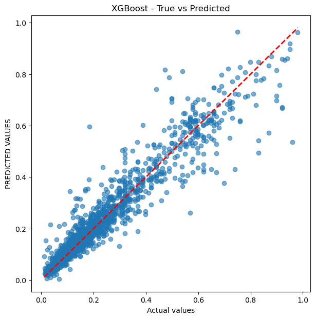

```python
# -*- coding: utf-8 -*-

import pandas as pd
import joblib
from sklearn.metrics import mean_absolute_error, mean_squared_error, r2_score
import numpy as np
import matplotlib.pyplot as plt

# -----------------------------
# 1) تحميل الموديل
# -----------------------------
model = joblib.load("xgb_best_model.pkl")

# -----------------------------
# 2) قراءة بيانات الاختبار (لو موجودة)
# -----------------------------
# لو لسه X_test و y_test موجودين في الجلسة، استخدمهم مباشرة
# أما لو عندك CSV:
# test_data = pd.read_csv("test_data.csv")
# X_test = test_data.drop("Price", axis=1)
# y_test = test_data["Price"]

# -----------------------------
# 3) التنبؤ
# -----------------------------
y_pred = model.predict(X_test)

# -----------------------------
# 4) حساب Metrics
# -----------------------------
mae = mean_absolute_error(y_test, y_pred)
rmse = np.sqrt(mean_squared_error(y_test, y_pred))
r2 = r2_score(y_test, y_pred)

print("=============== MODEL PERFORMANCE ===============")
print(f"MAE   : {mae:.4f}")
print(f"RMSE  : {rmse:.4f}")
print(f"R²    : {r2:.4f}")

# -----------------------------
# 5) عرض بعض التوقعات
# -----------------------------
print("\nبعض التوقعات مقابل الحقيقة:")
for real, pred in zip(y_test[:10], y_pred[:10]):
    print(f"حقيقي: {real:.4f} - متوقع: {pred:.4f}")

# -----------------------------
# 6) رسم Scatter Plot
# -----------------------------
plt.figure(figsize=(7,7))
plt.scatter(y_test, y_pred, alpha=0.6)
plt.plot([y_test.min(), y_test.max()], [y_test.min(), y_test.max()], 'r--', lw=2)
plt.xlabel("Actual values")
plt.ylabel("PREDICTED VALUES")
plt.title("XGBoost - True vs Predicted")
plt.show()
```

```
=============== MODEL EVALUATION ===============
  Metric     Value
0    MAE  0.029599
1    MSE  0.002708
2   RMSE  0.052037
3     R²  0.916456

بعض التوقعات مقابل الحقيقة:
حقيقي: 0.0902 - متوقع: 0.1111
حقيقي: 0.1423 - متوقع: 0.1731
حقيقي: 0.0842 - متوقع: 0.0572
حقيقي: 0.4389 - متوقع: 0.7416
حقيقي: 0.1583 - متوقع: 0.1969
حقيقي: 0.0762 - متوقع: 0.0775
حقيقي: 0.2184 - متوقع: 0.1974
حقيقي: 0.2585 - متوقع: 0.2760
حقيقي: 0.2134 - متوقع: 0.1984
حقيقي: 0.1643 - متوقع: 0.1584
```

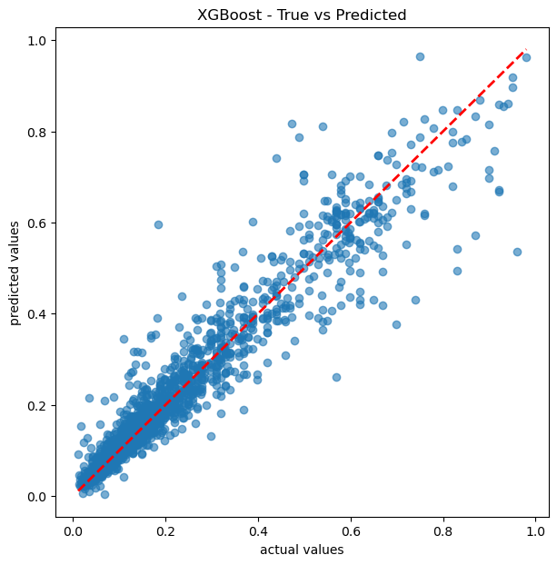

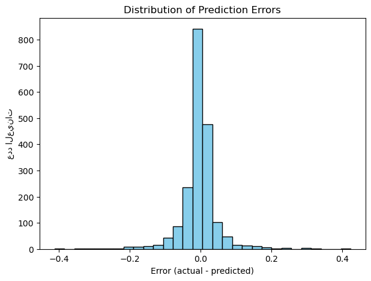

```python
# -*- coding: utf-8 -*-

import pandas as pd
import joblib
from sklearn.metrics import mean_absolute_error, mean_squared_error, r2_score
import numpy as np
import matplotlib.pyplot as plt

# -----------------------------
# 1) تحميل الموديل
# -----------------------------
model = joblib.load("xgb_best_model.pkl")

# -----------------------------
# 2) بيانات الاختبار
# -----------------------------
# لو X_test و y_test موجودين في الجلسة استخدمهم مباشرة
# لو من CSV:
# test_data = pd.read_csv("test_data.csv")
# X_test = test_data.drop("Price", axis=1)
# y_test = test_data["Price"]

# -----------------------------
# 3) التنبؤ
# -----------------------------
y_pred = model.predict(X_test)
errors = y_test - y_pred

# -----------------------------
# 4) حساب Metrics
# -----------------------------
mae = mean_absolute_error(y_test, y_pred)
rmse = np.sqrt(mean_squared_error(y_test, y_pred))
r2 = r2_score(y_test, y_pred)
mse = mean_squared_error(y_test, y_pred)

# طباعة ملخص Evaluation
evaluation_df = pd.DataFrame({
    "Metric": ["MAE", "MSE", "RMSE", "R²"],
    "Value": [mae, mse, rmse, r2]
})

print("=============== MODEL EVALUATION ===============")
print(evaluation_df)

# -----------------------------
# 5) عرض بعض التوقعات
# -----------------------------
print("\nبعض التوقعات مقابل الحقيقة:")
for real, pred in zip(y_test[:10], y_pred[:10]):
    print(f"حقيقي: {real:.4f} - متوقع: {pred:.4f}")

# -----------------------------
# 6) Scatter Plot
# -----------------------------
plt.figure(figsize=(7,7))
plt.scatter(y_test, y_pred, alpha=0.6)
plt.plot([y_test.min(), y_test.max()], [y_test.min(), y_test.max()], 'r--', lw=2)
plt.xlabel("actual values")
plt.ylabel("predicted values")
plt.title("XGBoost - True vs Predicted")
plt.show()

# -----------------------------
# 7) Histogram للخطأ
# -----------------------------
plt.figure(figsize=(7,5))
plt.hist(errors, bins=30, color='skyblue', edgecolor='black')
plt.xlabel("Error (actual - predicted)")
plt.ylabel("عدد العينات")
plt.title("Distribution of Prediction Errors")
plt.show()
```

# **Using My Model To Predict New Data**

```python
import pickle
```

```python
file_name='Car_Predictions.sav'
```

```python
import pickle

with open("xgbo_best_model.pkl", "rb") as f:
    data = pickle.load(f)

print(type(data))
print(data)
```

```
<class 'xgboost.sklearn.XGBRegressor'>
XGBRegressor(base_score=None, booster=None, callbacks=None,
             colsample_bylevel=None, colsample_bynode=None,
             colsample_bytree=None, device=None, early_stopping_rounds=None,
             enable_categorical=False, eval_metric=None, feature_types=None,
             feature_weights=None, gamma=None, grow_policy=None,
             importance_type=None, interaction_constraints=None,
             learning_rate=None, max_bin=None, max_cat_threshold=None,
             max_cat_to_onehot=None, max_delta_step=None, max_depth=None,
             max_leaves=None, min_child_weight=None, missing=nan,
             monotone_constraints=None, multi_strategy=None, n_estimators=None,
             n_jobs=None, num_parallel_tree=None, ...)
```

```python
if hasattr(model, "get_booster"):
    print("الأعمدة اللي اتدرب عليها الموديل:")
    print(model.get_booster().feature_names)
else:
    print("الموديل لا يحتفظ بأسماء الأعمدة (ربما تم التدريب على NumPy Array)")
```

```
الأعمدة اللي اتدرب عليها الموديل:
['Make', 'Model', 'Year', 'Mileage_in_KM', 'Transmission', 'City', 'Color', 'Fuel_Type', 'Body_Style']
```

```python
import pickle
import xgboost as xgb

# افترض أن best_model هو الموديل بعد التدريب
best_model = xgb.XGBRegressor()
best_model.fit(X_train, y_train)  # التدريب هنا

# حفظ الموديل فقط
with open("xgbo_best_model.pkl", "wb") as f:
    pickle.dump(best_model, f)
```

```python
with open("xgbo_best_model.pkl", "rb") as f:
    model = pickle.load(f)

print(type(model))
# يجب أن يظهر: <class 'xgboost.sklearn.XGBRegressor'>
```

```
<class 'xgboost.sklearn.XGBRegressor'>
```